# Merging World Endangered Language data with World Education Statistic and Elevation

@xhoong

Previously we have tidy up education statistics acquired from World Bank and have chosen statistics from Barro-Lee. Now we are merging this data set with the original endangered languages list together with obtained elevation from Google.

```r
library(DT)
set.seed(123)
yr<-gsub(".*\\b([0-9]{4})\\b.*", "\\1", ext.lang.elevation$Sources)
sort(unique(gsub("[^0-9]{4}.*", "", unique(yr))))
```

```
##  [1] ""     "1596" "1930" "1932" "1952" "1959" "1966" "1967" "1976" "1977"
## [11] "1979" "1981" "1982" "1983" "1985" "1986" "1987" "1988" "1989" "1991"
## [21] "1992" "1993" "1994" "1995" "1996" "1997" "1998" "1999" "2000" "2001"
## [31] "2002" "2003" "2004" "2005" "2006" "2007" "2008" "2009"
```

```r
edstats.barrolee<-filterByYearUnstack(edstats, 1980, 2016) %>% getColByName (colname="Barro-Lee.*", Country.Code, year)
barrolee.freq<-seq(1980, 2010, by=5)
BarroLee<-which(grepl("Barro-Lee.*", names(edstats.barrolee)))
edstats.barrolee<-bind_rows(sapply(barrolee.freq,
                                     function(x) edstats.barrolee %>% filter(year==as.character(x)), simplify = F))
```

Not all country code listed in the World Bank education statistics is covered by Barro-Lee, here, we select the country that is listed.

```r
country.code.no.data<-unique(apply(
  edstats.barrolee[edstats.barrolee$year=="1980",], 2,
  function(x) length(which(is.na(x)))))[1]
a<-which(apply(edstats.barrolee[1:242,], 1, function(x) sum(is.na(x))) > 0) ## Country with no statistics
```

Below are the list of countries that is in World Bank data set but not in Barro-Lee data.

```r
sapply(edstats.barrolee[a, "Country.Code"],
         function(x) edstats[edstats$Country.Code==x, "Country.Name"][1])
```

```
##  [1] Aruba
##  [2] Andorra
##  [3] Angola
##  [4] Arab World
##  [5] American Samoa
##  [6] Antigua and Barbuda
##  [7] Azerbaijan
##  [8] Burkina Faso
##  [9] Bahamas, The
## [10] Bosnia and Herzegovina
## [11] Belarus
## [12] Bermuda
## [13] Bhutan
## [14] Channel Islands
## [15] Comoros
```

[output cut: 84 more lines]

We filter the 98 countries stated above and also took out variables that is stating the country population. The Barro-Lee statistics are in percentage form, so the value already normalize to each country.

```r
edstats.barrolee.l<-edstats.barrolee %>% filter(!(Country.Code %in% edstats.barrolee[a, "Country.Code"]))
b<-grep("Population", names(edstats.barrolee.l))  ## Take out Population statistics
edstats.barrolee.l<- edstats.barrolee.l %>% select(-b)
```

Finally we find the differences in countries covered in language endangered list and Barro-Lee education statistics, this result in 10.7% data being drop from the language endangered list.

```r
c<-setdiff(ext.lang.elevation$Country.codes.alpha.3.coord, edstats.barrolee.l$Country.Code)
round(sum(sapply(c,
                 function(x)
                   length(
                     ext.lang.elevation[ext.lang.elevation$Country.codes.alpha.3.coord==x,
                                        "Countries"]))) / nrow(ext.lang.elevation), 3) * 100
```

```
## [1] 10.7
```

```r
## 10.7% no data with Barro Lee
```

### Showing sample of merged data

```r
# edstats.barrolee.2000<-edstats.barrolee.l %>% filter(year == "2000")
## Take out country from extinction list that not included in Barro-Lee stats 10.7%
## Take out language with no Number of Speakers data 6.7%
new.ext<-ext.lang.elevation %>% filter(!(Country.codes.alpha.3.coord %in% c)) %>%
  filter(!is.na(Number.of.speakers)) %>%
  select(ID, Degree.of.endangerment, Name.in.English, Number.of.speakers, elevation, Country.codes.alpha.3.coord )
total.speakers<-sum(new.ext$Number.of.speakers)
new.ext<-new.ext %>% mutate(Number.of.speakers.pct = (Number.of.speakers/total.speakers)*100)
## Merge for all years
new.ext<-merge(new.ext, edstats.barrolee.l, by.x="Country.codes.alpha.3.coord",
               by.y = "Country.Code", all.x=T) %>% select ( - matches("year") )
showTable(new.ext[1:1000,] %>% select (1, 3:8))
```

|  | Country.codes.alpha.3.coord | Degree.of.endangerment | Name.in.English | Number.of.speakers | elevation | Number.of.speakers.pct | Barro-Lee: Percentage of female population age 15-19 with no education |
| --- | --- | --- | --- | --- | --- | --- | --- |
| 1 | AFG | Severely endangered | Munji | 2000 | 3441.03686523438 | 0.00160939175364242 | 69.52 |
| 2 | AFG | Severely endangered | Munji | 2000 | 3441.03686523438 | 0.00160939175364242 | 84.2 |
| 3 | AFG | Severely endangered | Munji | 2000 | 3441.03686523438 | 0.00160939175364242 | 87.5 |
| 4 | AFG | Severely endangered | Munji | 2000 | 3441.03686523438 | 0.00160939175364242 | 85.5 |
| 5 | AFG | Severely endangered | Munji | 2000 | 3441.03686523438 | 0.00160939175364242 | 82.35 |
| 6 | AFG | Severely endangered | Munji | 2000 | 3441.03686523438 | 0.00160939175364242 | 82.68 |
| 7 | AFG | Severely endangered | Munji | 2000 | 3441.03686523438 | 0.00160939175364242 | 59.18 |
| 8 | AFG | Definitely endangered | Kati | 18700 | 2207.03125 | 0.0150478128965566 | 69.52 |
| 9 | AFG | Definitely endangered | Kati | 18700 | 2207.03125 | 0.0150478128965566 | 84.2 |
| 10 | AFG | Definitely endangered | Kati | 18700 | 2207.03125 | 0.0150478128965566 | 87.5 |

[output cut: 990 more lines]

### Exploring clustering with PCA

We first try to compress the data and visualized if there’s any pattern that separate the language endangered levels with the variables we collected so far using PCA.

```r
library(RColorBrewer)
BarroLee<-which(grepl("Barro-Lee.*", names(new.ext)))
pca.data<-as.matrix(new.ext %>% select( elevation, Number.of.speakers.pct, BarroLee))

rownames(pca.data)<-as.character(new.ext$Degree.of.endangerment)
```

### PCA plot

Performing PCA and using rank to normalize the data, most of the data from Barro-Lee is stated as percentage which is normalized, the rank here mainly to normalize the elevation and number of speakers data.

```r
pca.barrolee <- princomp(apply(pca.data, 2, rank))
lambda <- (pca.barrolee$sdev)^2
propvar <- round(lambda / sum(lambda) * 100, 0)
doe.levels<-levels(factor(ext.lang.elevation$Degree.of.endangerment,
                   levels=c("Vulnerable", "Definitely endangered",
                            "Severely endangered", "Critically endangered", "Extinct")))
```

#### Plot of PCA relationship on 1-2, 1-3 and 2-3

Plotting with PC1 with PC2, PC1 with PC3 and PC2 with PC3 to find any pattern in the data, the coloring of points are with the levels of endangered languages.

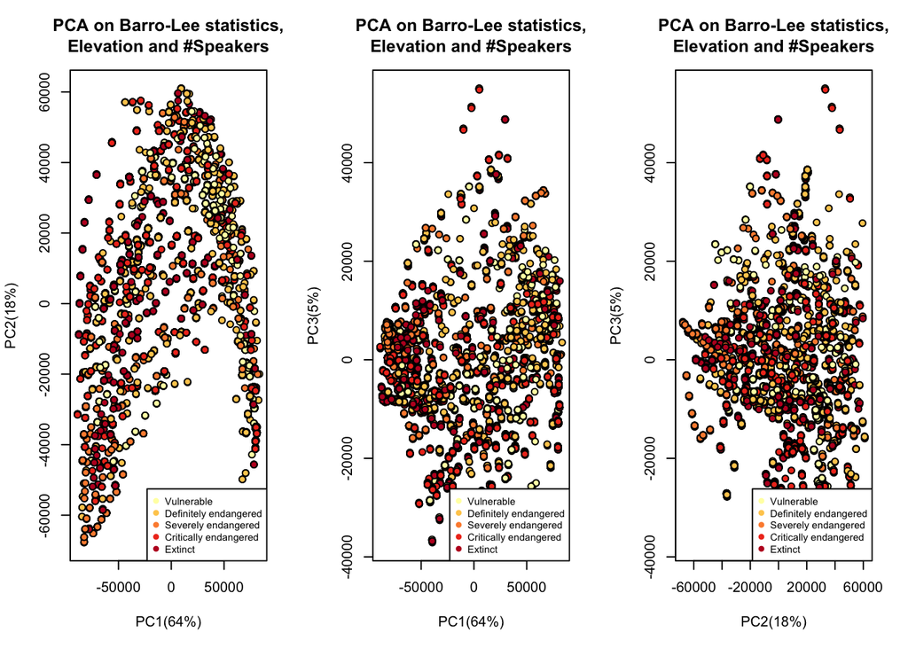

```r
par(mfrow=c(1,3))
t<-lapply(list(a=c(1,2), b=c(1,3), c=c(2,3)), function(x) {
plot(pca.barrolee$scores[,x[1]], pca.barrolee$scores[,x[2]], pch=21,
     xlab=paste(c("PC",x[1],"(",propvar[x[1]],"%)"), collapse=""), ylab=paste(c("PC",x[2],"(",propvar[x[2]],"%)"), collapse=""),
     bg=brewer.pal(5, "YlOrRd")[unclass(factor(new.ext$Degree.of.endangerment,
                                             levels=c("Vulnerable", "Definitely endangered",
                                                      "Severely endangered", "Critically endangered", "Extinct")))])

legend("bottomright", doe.levels, col=brewer.pal(5, "YlOrRd"),
       cex=0.7,
       pch=rep(19, length(doe.levels)))
title("PCA on Barro-Lee statistics,\nElevation and #Speakers")

})
```

```r
par(mfrow=c(1,1))
```

#### PCA plot on PC1 and PC2

Bigger plot on PC1 vs PC2, there’s apparent pull in 2 end of PC1 scale, but there’s no apparent cluster form in plot.

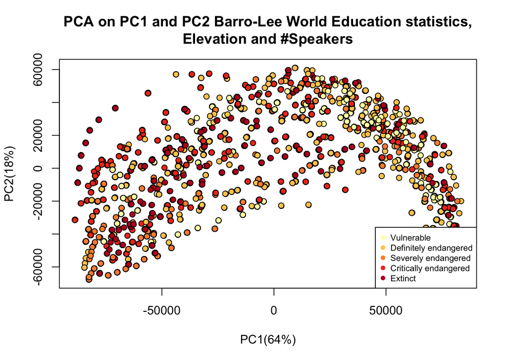

```r
color<-brewer.pal(5, "YlOrRd")
# color<-c(rep("blue", 2), rep("red", 3))
plot(pca.barrolee$scores[,1], pca.barrolee$scores[,2], pch=21,
     xlab=paste(c("PC",1,"(",propvar[1],"%)"), collapse=""), ylab=paste(c("PC",2,"(",propvar[2],"%)"), collapse=""),
     bg=color[unclass(factor(new.ext$Degree.of.endangerment,
                                               levels=c("Vulnerable", "Definitely endangered",
                                                        "Severely endangered", "Critically endangered", "Extinct")))])

legend("bottomright", doe.levels, col=brewer.pal(5, "YlOrRd"),
       cex=0.7,
       pch=rep(19, length(doe.levels)))
title("PCA on PC1 and PC2 Barro-Lee World Education statistics,\nElevation and #Speakers")
```

### Observation

So far we have not identify any substantial clustering based on education as main contribution factor to language endangerment risk. We will continue to merge data from each country GDP and climate variability factors sucs as precipitation.

### Appendix

Reading the World Bank education statistics and our first enriched language extinction data set with Elevation and country reference tidy data.

```r
require(reshape2)
require(dplyr)
edstats<-read.csv("../input/Edstats_csv/Edstats_Data.csv")
ext.lang.elevation<-readRDS(file="collected_data/ext.lang.elevation.country.normalized.RDS")
```

Reusing function from World Education Statistic for unstack the data from world bank

```r
filterByYearUnstack<-function(edstats.df, fromYear=1976, toYear=2016) {
  getYear<-function(yr) {
    as.numeric(gsub("X([0-9]{4})", "\\1", yr))
  }
  edstats.years<-data.frame()
  for(n in names(edstats)) {
    if (grepl("X[0-9]{4}", n) && getYear(n) >=fromYear && getYear(n) <= toYear)
      edstats.years<-rbind(edstats.years, edstats.df %>%
                                  dcast(Country.Code~Indicator.Name, value.var= n) %>%
                                  mutate(year=gsub("X([0-9]{4})", "\\1", n)))
  }
  edstats.years
}

getColByName<-function(.data, colname, ... ) select(.data, which(grepl(colname, names(.data))), ...)

showTable<-function(data) {
  datatable(data, options = list(pageLength = 10))
}
```